# June 18: Changing investment and dividends

### Summary of the model

Here are the equations that make up the economic side of the model:

Output:
$$Y^0 := \frac{K}{\nu}$$

Output after damages:
$$Y := (1 - \mathbf{D}^Y)(1 - A) Y^0$$

Climate change abatement:
$$A := \frac{\sigma p_{BS} n^{\theta}}{\theta}$$

The emissions reduction rate:
$$n = \min{\left\{ \left(\frac{p_{C}}{(1 - s_{A}) p_{BS}}\right)^\frac{1}{\theta - 1} \, , \, 1\right\}}$$

Employed persons:
$$L := \frac{Y^0}{a}$$

Labour productivity:
$$\dot{a} := \alpha \: a$$

Population:
$$\dot{N} := \delta_{N} N \left(1 - \frac{N}{\overline{N}}\right)$$

Employment rate:
$$\lambda := \frac{L}{N}$$

Phillips curve relationship between wages and the employment rate:
$$\dot{w} := w \: \Phi (\lambda)$$

Wage share of output:
$$\omega := \frac{w L}{p Y}$$

Differential equation for prices:
$$\dot{p}:= p \, \eta \, (\mu \omega - 1)$$

The important part for our current discussions is the part of the model dealing with profit, debt, and investment.

#### Total profits:

$$\Pi := p Y - w L - \delta_{\mathbf{D}^K} p K - r D + p \Upsilon$$

#### Profit share:

$$\pi := \frac{\Pi}{p Y}$$

#### Dividends (changed):

This is one thing I changed: now dividends are a fraction of profit (before they were a fraction of nominal output).
$$\Pi_{d} := \Delta(\pi) \Pi$$

$$\Pi_{r} := \Pi - \Pi_{d} \\
\pi_r = \frac{\Pi_{r}}{p Y}$$

Now I also compute a retained profit share ($\pi_r$), which is used in computing investment.

#### Real investment (changed):

$$I := \kappa(\pi_r) Y$$

where the investment function $\kappa(\pi)$ is function of the *retained* profit share (this is the change as before $\kappa$ was a function of the profit share, $\pi$). The result $\kappa(\pi) \in [0,1]$ returns the fraction of (real) output invested.

#### Debt dynamics:

$$\dot{D} := p (I - \delta_{\mathbf{D}^K} K) - \Pi_{r}$$

#### Capital dynamics:

$$\dot{K} := I - \delta_{\mathbf{D}^K} K$$

## Calibrating the dividend and investment functions

I spent time calibrating the dividend and investment functions. My criteria were that the following three key ratios should be respected:

1. First, define Goodwin profits to be nominal output minus the wage bill: $\Pi_{Gdwn} = p Y - w L$. Then we should have $\frac{p I}{\Pi_{Gdwn}} = 0.6-0.8$, as was estimated by Grasselli and Maheshwari (2018).
2. Second, investment should be about 20-25% of total output: $\frac{I}{Y} = 0.2-0.25$.
3. Third, dividends should be between 20 and 50% of total profits: $\frac{\Pi_d}{\Pi} = 0.2 - 0.5$.

#### Dividend function:

The functional form is a linear function, $\Pi_d = \mu_0 + \mu_1 \pi$, that is constrained with a maximum and minimum value. This is the form given in both AFD papers, though they use different parameters in each paper. Below I set the values for the function.

```r
Pars['div_constant'] = 0.3
Pars['div_slope']    = 0.5
Pars['div_min']      = 0
Pars['div_max']      = 0.5
```

I chose these values after experimenting with many different specifications. These parameters keep dividends to be about 30 to 50 % of total profits, though the choice of investment curve does somewhat affect the dividends paid as well. The curve looks like this:

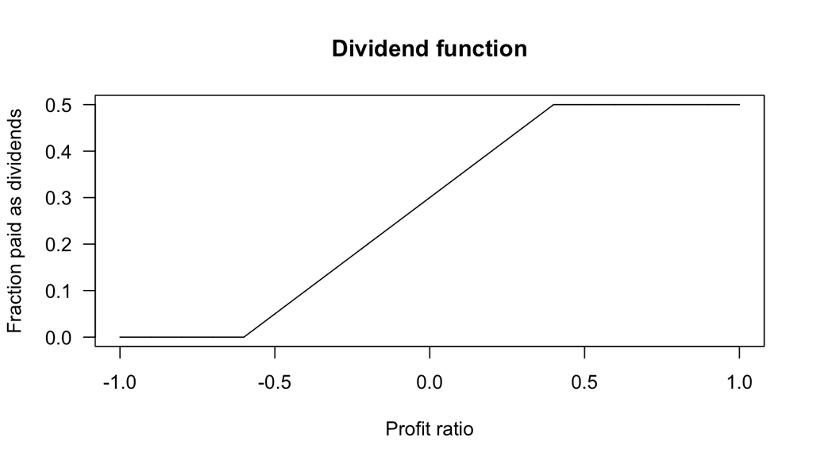

#### Investment function:

I use two functional forms for investment. The first is a linear function, constrained with a maximum and minimum value, as was used in Bovari et al. (2018a, 2018b), ie. $I = \kappa_0 + \kappa_1 \pi$. I changed the parameters, aiming to stay with the bounds of the two ratios that include investment. Below I set the values for the function

```r
### Investment function parameters
Pars['I_lin_constant'] = 0.1
Pars['I_lin_slope']    = 0.8
Pars['I_lin_max']      = 0.5
Pars['I_lin_min']      = 0
```

which gives the following investment curve:

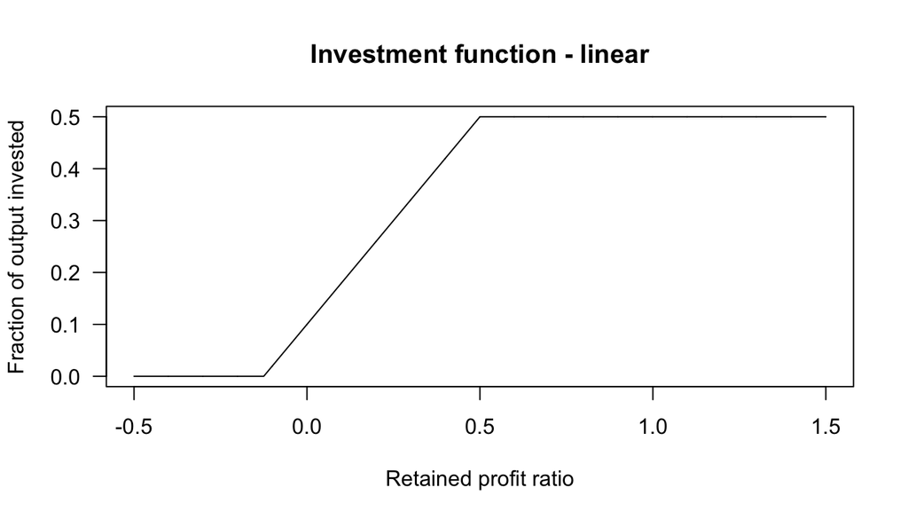

Again, I will explore the dynamics of the model using three scenarios. The first uses the initial conditions from Bovari et al. (2018b).

```r
IC_1 <- c(
  # Economic variables
  Y_N       =  30,       # global GDP, in trillions of USD
  d_N       =  1.5,      # private debt ratio of the economy
  lambda_N  =  0.67,     # employment rate of the global economy
  omega_N   =  0.58,     # wage share of the economy
  N_N       =  2.4,      # Workforce of the (world) economy, in billions /2
  g_sigma_N =  -0.0105,  # Growth rate of the emissions intensity of the economy
  n_N       =  0.03,     # Emissions reduction rate
  E_ind_N   =  18,       # Industrial CO2-e emissions, in Gt CO2-e

  # Climate variables - unchanged in all scenarios
  CO2_AT   =  851,      # CO2-e concentration in the atmosphere layer, in Gt C
  CO2_UP   =  460,      # CO2-e concentration in the biosphere and upper ocean layer, in Gt C
  CO2_LO   =  1740,     # CO2-e concentration in the deep ocean layer, in Gt C
  E_land   =  2.6,      # Exogenous land use change CO2-e emissions, in Gt CO2-e
  p        =  1,        # Composite good price level
  p_BS     =  547.22,   # Backstop technology price level
  Temp     =  0.85,     # Temperature in the atmosphere, biosphere, and upper ocean layer, in degrees Celsius
  Temp_LO  =  0.0068    # Temperature in the deep ocean layer, in degrees Celsius
)
```

In the second scenario, I make the initial conditions more favourable.

```r
IC_2 <- c(
  # Economic variables
  Y_N       =  40,       # changed
  d_N       =  0.6,      # changed
  lambda_N  =  0.9,      # changed
  omega_N   =  0.6,      # changed
  N_N       =  2.4,
  g_sigma_N =  -0.0105,
  n_N       =  0.03,
  E_ind_N   =  18,

  # Climate variables - unchanged in all scenarios
  CO2_AT   =  851,
  CO2_UP   =  460,
  CO2_LO   =  1740,
  E_land   =  2.6,
  p        =  1,
  p_BS     =  547.22,
  Temp     =  0.85,
  Temp_LO  =  0.0068
)
```

In the third scenario, the initial conditions are worse than the AFD conditions:

```r
IC_3 <- c(
  # Economic variables
  Y_N       =  20,       # changed
  d_N       =  2,        # changed
  lambda_N  =  0.5,      # changed
  omega_N   =  0.45,
  N_N       =  2.4,
  g_sigma_N =  -0.0105,
  n_N       =  0.03,
  E_ind_N   =  18,

  # Climate variables - unchanged in all scenarios
  CO2_AT   =  851,
  CO2_UP   =  460,
  CO2_LO   =  1740,
  E_land   =  2.6,
  p        =  1,
  p_BS     =  547.22,
  Temp     =  0.85,
  Temp_LO  =  0.0068
)
```

I run the three scenarios (normal initial conditions, better, and worse) to 2200, so as to see what happens to those key ratios I mentioned before in the long run.

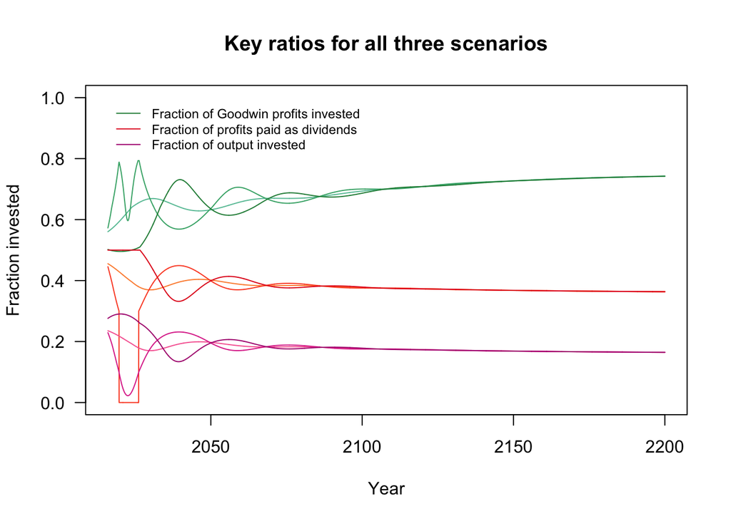

The red-purple lines, $\frac{\Pi_d}{\Pi}$ are at about 0.4, within the range of 0.2-0.5.

Finally, the orange lines are at about 0.2, within the range of 0.2 - 0.25.

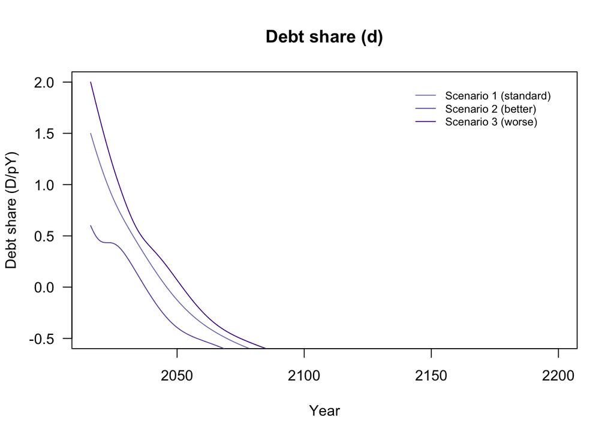

## Changing to a smooth investment function

I can instead use the arctan investment curve suggested by Grasselli and Costa Lima (2014): $I = \kappa_0 + \kappa_1 \arctan ( \kappa_2 \pi_r + \kappa_3)$. I make the investment function more aggressive than they had, because investment is now a function of *retained* profit.

```r
Pars['kappa_0'] = 0.5          # Costa Lima et al. (2014)
Pars['kappa_1'] = 0.31831      # Costa Lima et al. (2014)
Pars['kappa_2'] = 12           # changed
Pars['kappa_3'] = -3           # changed
```

The investment function looks like this:

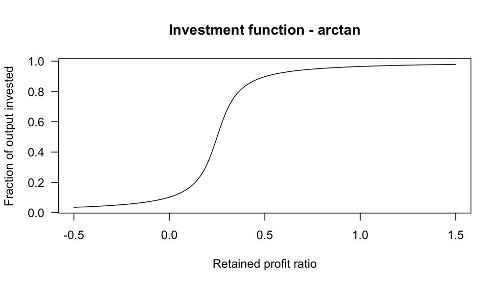

Again I run the three scenarios (normal initial conditions, better, and worse) and look at those key ratios:

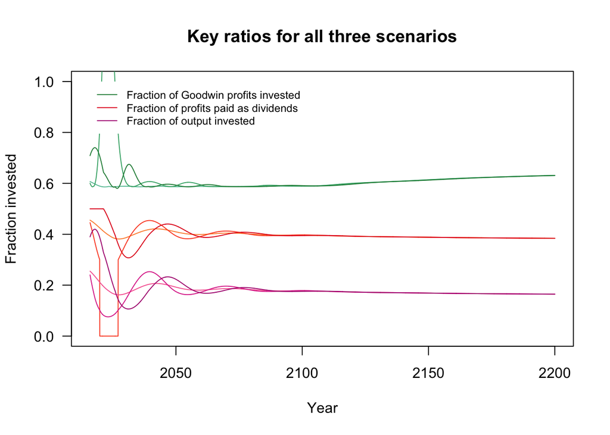

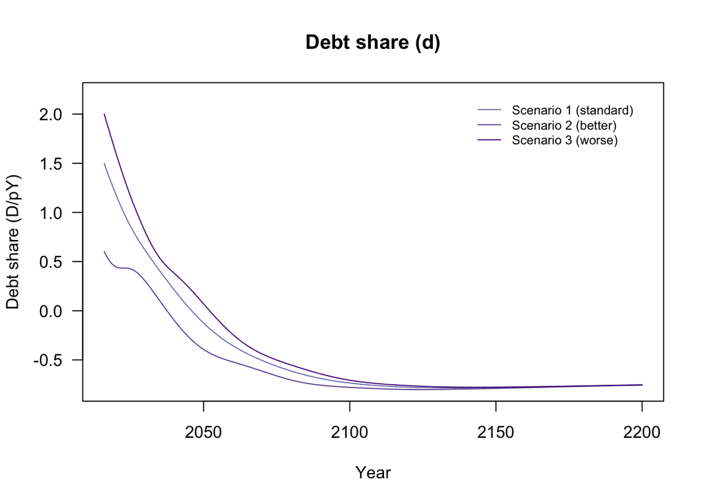

## Final thoughts

I think the model described above, with the arctan investment curve, has promise. We can discuss how to further refine the choice of curves. The next steps for me are to implement this model for two regions, and then run the code that checks for instability based on small changes in initial conditions. The issue of the model still going to the positive equilibrium even with very unfavourable initial conditions remains.